# Grappling with the “Sensory seeking” scale

Last updated 2018-04-07

Here we look at the “sensory seeking” scale (Brown et al.; Packet 2) in detail.

# Differences across fieldsites

## Mean scores by site

First, let’s look at scores for participants in each site:

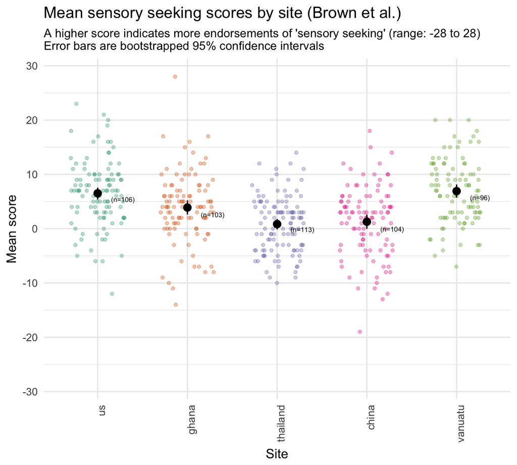

Note that this plot includes both average scores for each site (in black), and individual scores for all of the participants in that site (small, colorful points in the background, which are “jittered” around a little so that you can see them all).

Looks like people in different sites responded somewhat differently to this scale! Participants in the US and Vanuatu responded somewhat more positively; participants in Thailand and China somewhat more neutrally/negatively.

Now let’s look at these differences in more detail using the “raw data” for individual questions, rather than these subscale scores.

## Responses by question, by site

```
Column `question` joining character vector and factor, coercing into character vectorIgnoring unknown aesthetics: fill
```

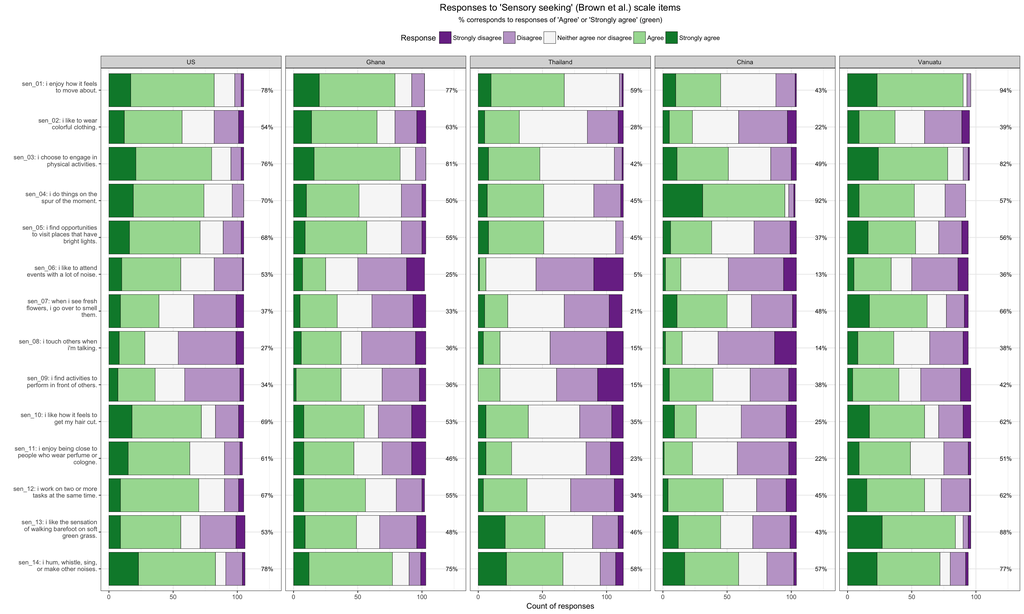

As always, lots to chew on here. Off the top of my head, a few things stand out:

- More use of the neutral midpoint in TH and CH, as we anticipated in informal discussions.
- At a glance, it seems like plenty of people in VT were using the “disagree” end of the scale (purple)… though let’s also look at this at an individual level (below).
- People in CH really tended to agree that they “like to do things on the spur of the moment”! (`sen_04`)
- People in the US tended to say they liked events with loud noises more than people in other places; people in TH tended to disagree pretty strongly. (`sen_06`)
- People in CH and VT seemed to be more attuned to smelling flowers - especially interesting given that the CH sample was probably the most urban, and VT the most rural (calling **Josh**!). (`sen_07`)
- Relatedly, but with a somewhat different pattern, people in the US tended to say they liked when others wore perfume, but people in CH and (as **Felicity** might have predicted!) responded more negatively to this.
- Unsurprisingly, people in VT had stronger responses to “walking barefoot on soft green grass”.

**Josh**, you’ve gotta take a look at these with an eye toward a ratio! Maybe we should fold them into the “ratio of senses” doc…

This is just the tip of the iceberg. Tons to think through here.

# Distribution of responses for individual participants, by site

Another thing we might be interested in is how individual participants responded: Were there people who said yes to everything, or no to everything? How do these distributions of responses differ across participants in different sites?

Let’s take a look:

```
Column `question` joining character vector and factor, coercing into character vector
```

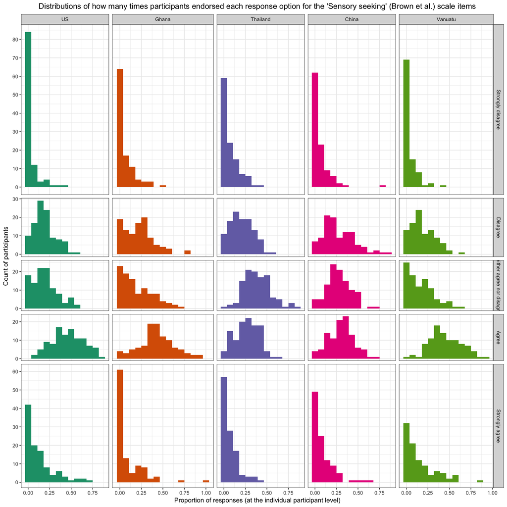

Again, lots to sort through here.

Just for fun, here’s another way to look at the same data, overlaying the density distributions for each site on top of each other to see where they seem to be similar/different:

```
Column `question` joining character vector and factor, coercing into character vector
```

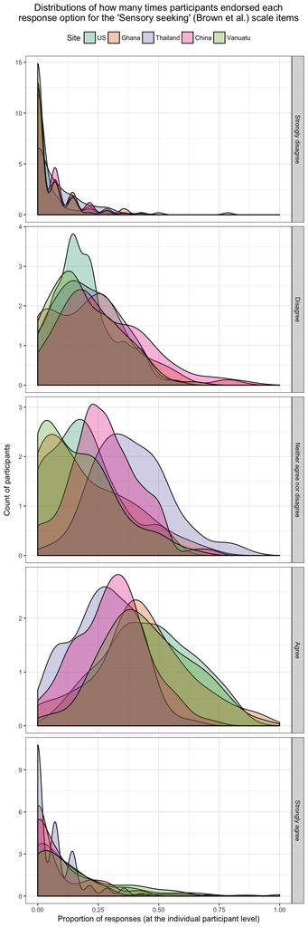